# Practical Machine Learning assignment

Carlos Santillan

January 27, 2016

# Practical Machine Learning

## Synopsis

Background

Using devices such as Jawbone Up, Nike FuelBand, and Fitbit it is now possible to collect a large amount of data about personal activity relatively inexpensively. These type of devices are part of the quantified self movement - a group of enthusiasts who take measurements about themselves regularly to improve their health, to find patterns in their behavior, or because they are tech geeks. One thing that people regularly do is quantify how much of a particular activity they do, but they rarely quantify how well they do it. In this project, your goal will be to use data from accelerometers on the belt, forearm, arm, and dumbell of 6 participants. They were asked to perform barbell lifts correctly and incorrectly in 5 different ways. More information is available from the website here: http://groupware.les.inf.puc-rio.br/har (see the section on the Weight Lifting Exercise Dataset).

The training data for this project are available here:

https://d396qusza40orc.cloudfront.net/predmachlearn/pml-training.csv

The test data are available here:

https://d396qusza40orc.cloudfront.net/predmachlearn/pml-testing.csv

The data for this project come from this source: http://groupware.les.inf.puc-rio.br/har

# Data Processing

Check if data is available , if not download it from repository and load

```r
setwd("E:/data/ML")
#check if directory exists
if (!file.exists("data"))
{
  dir.create("data")
}
if (!file.exists("data/pml-training.csv")) {
  download.file("http://d396qusza40orc.cloudfront.net/predmachlearn/pml-training.csv", destfile = "data/pml-training.csv")
}
if (!file.exists("data/pml-testing.csv")) {
  download.file("http://d396qusza40orc.cloudfront.net/predmachlearn/pml-testing.csv", destfile = "data/pml-testing.csv")
}
pmlTesting <- read.csv("data/pml-testing.csv", sep = ",", na.strings = c("", "NA"))
pmlTraining <- read.csv("data/pml-training.csv", sep = ",", na.strings = c("", "NA"))
```

## Loading and Preprocession of the data

Loading the file, and do a bit of data cleanup

```r
# Load the Training Dataset
pmlTraining <- read.csv("data/pml-training.csv", sep = ",", na.strings = c("", "NA"))

# Load the Testing Dataset
pmlTesting <- read.csv("data/pml-testing.csv", sep = ",", na.strings = c("", "NA"))

# remove variables that are moslty NA
pmlTraining <- pmlTraining[ , colSums(is.na(pmlTraining)) == 0]

# remove non predictive variables
CleanIndex <-  which(names(pmlTraining) %in% c('X', 'user_name', 'raw_timestamp_part_1', 'raw_timestamp_part_2', 'cvtd_timestamp', 'new_window','num_window'))

pmlTraining <- pmlTraining[, -CleanIndex]

# Remove the classe variable (this is what we are trying to predict)
#pmlTraining <- pmlTraining[, -53]
```

# Analysis

Remove variables near Zero Variance since they do not contribute to the model Also remove variables that are Highly correlated

```r
# Remove variables near Zero Variance (they won't contribute to the model)
zv <- nearZeroVar(pmlTraining[sapply(pmlTraining, is.numeric)], saveMetrics = TRUE)
pmlTraining <- pmlTraining[, -zv[, 'nzv']==0]

pmlTrainingold <-pmlTraining
pmlTraining <-pmlTrainingold

correlMatrix <- cor(na.omit(pmlTraining[sapply(pmlTraining, is.numeric)]))

pmlTraining_low <- pmlTraining[,-findCorrelation(correlMatrix, cutoff = .90, verbose = TRUE)]
```

```
## Compare row 10  and column  1 with corr  0.992
##   Means:  0.27 vs 0.168 so flagging column 10
## Compare row 1  and column  9 with corr  0.925
##   Means:  0.25 vs 0.164 so flagging column 1
## Compare row 9  and column  4 with corr  0.928
##   Means:  0.233 vs 0.161 so flagging column 9
## Compare row 8  and column  2 with corr  0.966
##   Means:  0.245 vs 0.157 so flagging column 8
## Compare row 19  and column  18 with corr  0.918
##   Means:  0.091 vs 0.158 so flagging column 18
## Compare row 46  and column  31 with corr  0.914
##   Means:  0.101 vs 0.161 so flagging column 31
## Compare row 46  and column  33 with corr  0.933
##   Means:  0.083 vs 0.164 so flagging column 33
## All correlations <= 0.9
```

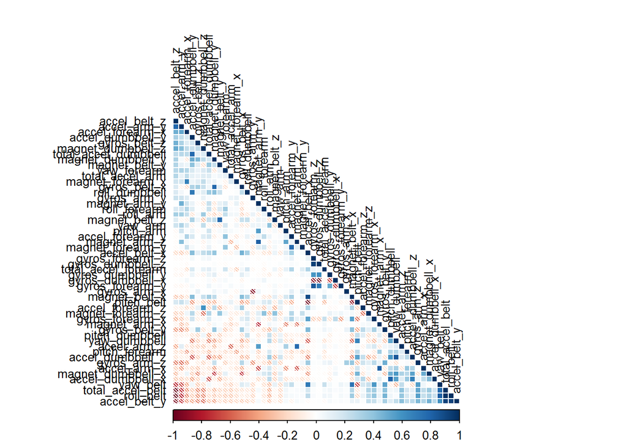

```r
corrplot(correlMatrix, order = "FPC", method = "shade", type = "lower", tl.cex = 0.8,
    tl.col = rgb(0, 0, 0))
```

```r
dim (pmlTraining_low)
```

```
## [1] 19622    46
```

We are not left with 46 Variables and 19,622 observations

## Generate Training an Test set to be used in cross validation

```r
 set.seed(123)

inTrain <- createDataPartition(y=pmlTraining_low$classe, p=0.8, list=FALSE)
trainingSet <- pmlTraining_low[inTrain,];   # 80%
testingSet  <- pmlTraining_low[-inTrain,]   # 20%
```

## Regression Tree

Train Models

```r
treeTraining=tree(classe~.,data=trainingSet)

modFit <- train(classe ~ .,method="rpart",data=trainingSet) #slow
print(modFit$finalModel)
```

```
## n= 15699
##
## node), split, n, loss, yval, (yprob)
##       * denotes terminal node
##
##  1) root 15699 11235 A (0.28 0.19 0.17 0.16 0.18)
##    2) pitch_forearm< -33.95 1269     6 A (1 0.0047 0 0 0) *
##    3) pitch_forearm>=-33.95 14430 11229 A (0.22 0.21 0.19 0.18 0.2)
##      6) magnet_belt_y>=554.5 13267 10067 A (0.24 0.23 0.21 0.18 0.15)
##       12) magnet_dumbbell_y< 439.5 11114  7979 A (0.28 0.18 0.24 0.17 0.13)
##         24) roll_forearm< 122.5 6997  4187 A (0.4 0.18 0.18 0.14 0.094) *
##         25) roll_forearm>=122.5 4117  2743 C (0.079 0.18 0.33 0.22 0.18)
##           50) accel_forearm_x>=-107.5 2912  1813 C (0.088 0.23 0.38 0.09 0.22) *
##           51) accel_forearm_x< -107.5 1205   558 D (0.058 0.082 0.23 0.54 0.095) *
##       13) magnet_dumbbell_y>=439.5 2153  1129 B (0.03 0.48 0.038 0.2 0.25) *
##      7) magnet_belt_y< 554.5 1163   233 E (0.00086 0.0026 0 0.2 0.8) *
```

### Plot our model

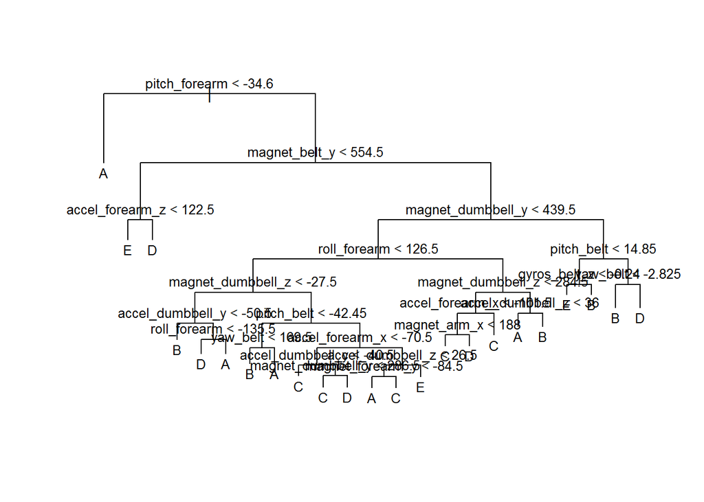

```r
plot(treeTraining)
text(treeTraining, cex =.8)
```

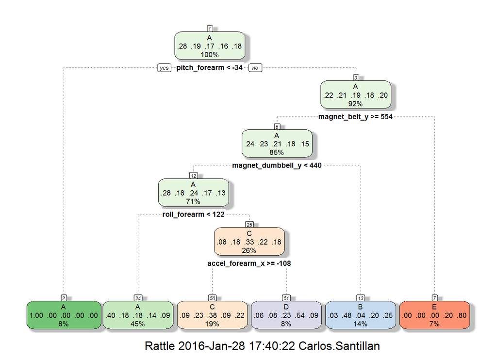

```r
fancyRpartPlot(modFit$finalModel)
```

```r
  testModel <- function (Predictions,testset)
  {
    predictionMatrix = with(testset,table(Predictions,classe))
    sum(diag(predictionMatrix))/sum(as.vector(predictionMatrix)) # error rate
  }
```

## Test Model

```r
  Predictions=predict(treeTraining,testingSet,type="class")
  testModel(Predictions,testingSet)
```

```
## [1] 0.6976803
```

```r
  Predictions=predict(modFit,testingSet)
  testModel(Predictions,testingSet)
```

```
## [1] 0.4998725
```

Not very good accuracy

## Cross Validate

```r
xvtraining=cv.tree(treeTraining,FUN=prune.misclass)
xvtraining
```

```
## $size
##  [1] 23 22 20 19 18 17 14 13 10  7  5  1
##
## $dev
##  [1]  4703  4753  5103  5184  5366  6033  6033  6426  7424  7784  8310
## [12] 11235
##
## $k
##  [1]     -Inf  88.0000 138.5000 151.0000 168.0000 191.0000 192.3333
##  [8] 198.0000 218.3333 253.6667 303.0000 731.7500
##
## $method
## [1] "misclass"
##
## attr(,"class")
## [1] "prune"         "tree.sequence"
```

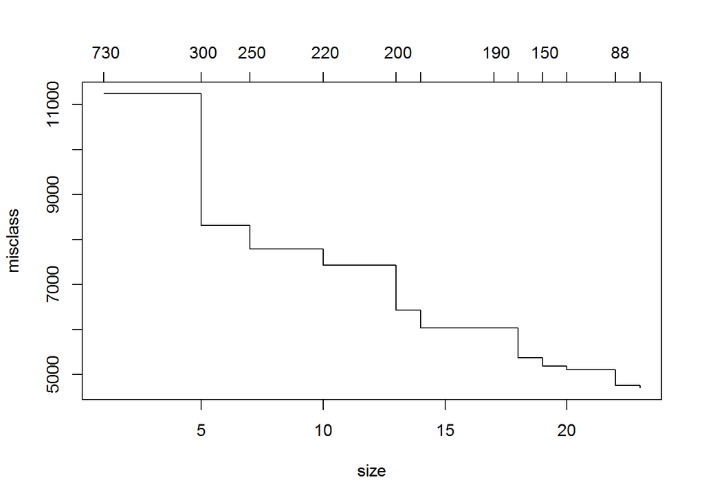

```r
plot(xvtraining)
```

lets prune and test

```r
prunetraining=prune.misclass(treeTraining,best=19)
Predictions=predict(prunetraining,testingSet,type="class")
testModel(Predictions,testingSet)
```

```
## [1] 0.6655621
```

## Random Forest

```r
rf=randomForest(classe~.,data=trainingSet,ntree=100, importance=TRUE)
rf
```

```
##
## Call:
##  randomForest(formula = classe ~ ., data = trainingSet, ntree = 100,      importance = TRUE)
##                Type of random forest: classification
##                      Number of trees: 100
## No. of variables tried at each split: 6
##
##         OOB estimate of  error rate: 0.59%
## Confusion matrix:
##      A    B    C    D    E class.error
## A 4457    4    0    1    2 0.001568100
## B   15 3017    4    1    1 0.006912442
## C    0   21 2713    4    0 0.009130752
## D    0    0   29 2542    2 0.012048193
## E    0    1    1    6 2878 0.002772003
```

Only used 6 variables at each split,

Plot Random foreset

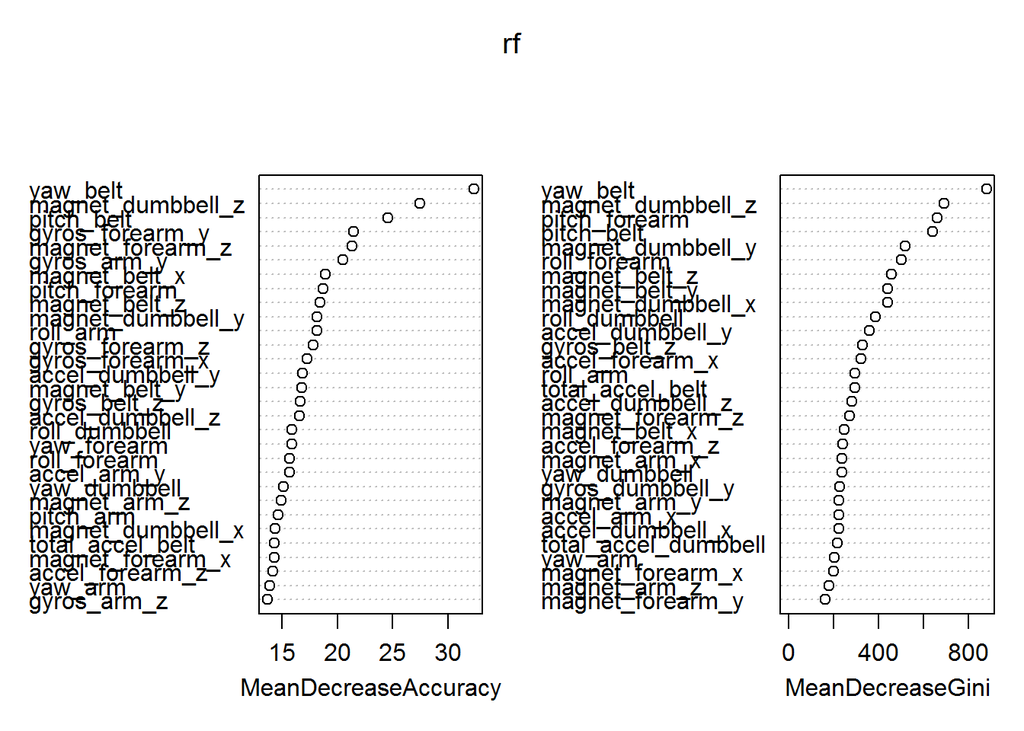

```r
  varImpPlot(rf,)
```

Test how random forest did

```r
Predictions=predict(rf,testingSet,type="class")
testModel(Predictions,testingSet)
```

```
## [1] 0.9949019
```

99% accuracy very good model

## lets make prediction

```r
finalpredictions <- predict(rf,pmlTesting)
finalpredictions
```

```
##  1  2  3  4  5  6  7  8  9 10 11 12 13 14 15 16 17 18 19 20
##  B  A  B  A  A  E  D  B  A  A  B  C  B  A  E  E  A  B  B  B
## Levels: A B C D E
```